# Sterile Insect Technique - ScienceDirect

## Cited By (31)

## Figures (2)

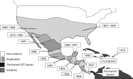

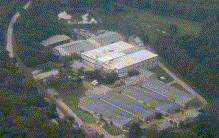

## [Encyclopedia of Insects (Second Edition)](https://www.sciencedirect.com/science/book/9780123741448)

2009, Pages 953-957

# Chapter 243 - Sterile Insect Technique

[JorgeHendrichs](https://www.sciencedirect.com/science/article/pii/B9780123741448002526#!)[AlanRobinson](https://www.sciencedirect.com/science/article/pii/B9780123741448002526#!)

https://doi.org/10.1016/B978-0-12-374144-8.00252-6[Get rights and content](https://s100.copyright.com/AppDispatchServlet?publisherName=ELS&contentID=B9780123741448002526&orderBeanReset=true)

## Publisher Summary

This chapter describes sterile insect techniques (SIT). It is a biologically based method for the control of key insect pests. Wild female insects inseminated by released, radiation-sterilized males do not reproduce, and repeated releases of the sterilized insects lead to a reduction in pest population numbers. Effective control using sterile insects is achieved when they are used systematically as part of area-wide integrated pest management (AW-IPM) programs. SIT is species-specific, nonpolluting, and resistance-free. Since the original concept was developed in the United States in the 1940s, SIT has been used successfully for screwworm flies, tsetse flies, fruit flies, and moths. Technical progress in behavioral ecology, mass rearing, strain improvement, global information, positioning and monitoring systems, and aerial release, combined with economies of scale and a growing demand for pest-free and low-pesticide agricultural products in local and international trade, have increased the use of SIT in AW-IPM programs. These programs, by decreasing insecticide use, have also facilitated the use of biological control agents against secondary insect pests.

## Cited by (31)

### Long term prevention and vector control of arboviral diseases: What does the future hold?

- 2019, International Journal of Infectious Diseases

  Citation Excerpt :

  Compared with the second most selected technology, the sterile insect technique (SIT), CRISPR/Cas9 provides both a lower release scale and lower duration and resistance to immigration pressure, reducing intervention time and costs (Adelman and Tu, 2016). Another possibly promising technology was SIT, which consists of releasing male insects that are sterilized using ionizing radiation (Hendrichs and Robinson, 2009). This technique has been used for some time and has proved effective for controlling insect populations.

### Methyl eugenol aromatherapy enhances the mating competitiveness of male Bactrocera carambolae Drew &amp; Hancock (Diptera: Tephritidae)

- 2014, Journal of Insect Physiology

  Citation Excerpt :

  Wild females that mate with sterile males produce no off-spring, and therefore the release of sterile males in adequate numbers reduces the wild population. In certain cases, this population suppression can lead to eventual eradication of the target population (Hendrichs and Robinson, 2009). Furthermore, as the SIT acts in an inverse density dependent manner, it becomes more effective when the wild population is reduced (Dyck et al., 2005b; Knipling, 1979; Vreysen et al., 2006).

### Fluctuating thermal regime preserves physiological homeostasis and reproductive capacity in Drosophila suzukii

- 2019, Journal of Insect Physiology

  Citation Excerpt :

  Once the larvae feed on the fruit flesh it becomes unsaleable, and infestations of D. suzukii therefore incur substantial economic loss associated with loss of crops, pest management and fruit selection (Bolda et al., 2010; Goodhue et al., 2011; Lee et al., 2011). A potential method to control pest insects such as D. suzukii is the sterile insect technique (SIT) where huge numbers of sterile males are released to outcompete fertile males that have invaded agricultural areas (Hendrichs and Robinson, 2009). The use of SIT, classical biocontrol methods, as well as incompatible insect technique (Zabalou et al., 2009) are currently under investigation in D. suzukii (Nikolouli et al., 2017) and it is therefore of interest to study how rearing and storing of this species can be optimised.

### Determination of the efficiency of diets for larval development in mass rearing Aedes aegypti (Diptera: Culicidae)

- 2018, Bulletin of Entomological Research

### Attractancy potential of bacterial volatiles from symbiotic bacteria of wild population of Zeugodacus cucurbitae Coquillett (Diptera:Tephritidae)

- 2022, Phytoparasitica

### Extended pre-release holding with raspberry ketone and methoprene as supplements: Field performance of Bactrocera tryoni males

- 2022, Journal of Applied Entomology

[View all citing articles on Scopus](http://www.scopus.com/scopus/inward/citedby.url?partnerID=10&rel=3.0.0&eid=2-s2.0-77957896929&md5=7765ff8e6b7caa9c6321aa7572abd)

Copyright © 2009 Elsevier Inc. All rights reserved.

[figure not shown]